# Aufgabenblatt 3

Vorhersage der Überlebensrate auf der Titanic mit logistischer Regression in R

Ömer Faruk Torun

2025-04-14

# Hintergrund

Sie sollen mithilfe von logistischer Regression und anderen Klassifikationsmethoden vorhersagen, ob ein Passagier die Titanic-Katastrophe überlebt hätte. Dazu nutzen Sie den Titanic-Datensatz und vergleichen verschiedene Modellansätze. Ihr Ziel ist es, durch Explorative Datenanalyse (EDA) und den Einsatz von verschiedenen Modellen eine möglichst präzise Vorhersage zu treffen. Anschließend testen Sie Ihr Modell mit neuen Passagieren.

# Schritt 1: Daten einlesen & erste Analyse (EDA)

Laden Sie den Titanic-Datensatz und verschaffen Sie sich mit glimpse() einen Überblick.

```r
library(tidyverse)
titanic_data <- read.csv("data/titanic.csv", sep = ";") %>%
  mutate(across(c(Survived, Pclass, Sex, Embarked), as.factor))
glimpse(titanic_data)
```

```
## Rows: 891
## Columns: 12
## $ PassengerId <int> 1, 2, 3, 4, 5, 6, 7, 8, 9, 10, 11, 12, 13, 14, 15, 16, 17,…
## $ Survived    <fct> 0, 1, 1, 1, 0, 0, 0, 0, 1, 1, 1, 1, 0, 0, 0, 1, 0, 1, 0, 1…
## $ Pclass      <fct> 3, 1, 3, 1, 3, 3, 1, 3, 3, 2, 3, 1, 3, 3, 3, 2, 3, 2, 3, 3…
## $ Name        <chr> "Braund, Mr. Owen Harris", "Cumings, Mrs. John Bradley (Fl…
## $ Sex         <fct> male, female, female, female, male, male, male, male, fema…
## $ Age         <dbl> 22, 38, 26, 35, 35, NA, 54, 2, 27, 14, 4, 58, 20, 39, 14, …
## $ SibSp       <int> 1, 1, 0, 1, 0, 0, 0, 3, 0, 1, 1, 0, 0, 1, 0, 0, 4, 0, 1, 0…
## $ Parch       <int> 0, 0, 0, 0, 0, 0, 0, 1, 2, 0, 1, 0, 0, 5, 0, 0, 1, 0, 0, 0…
## $ Ticket      <chr> "A/5 21171", "PC 17599", "STON/O2. 3101282", "113803", "37…
## $ Fare        <dbl> 45839.00, 712833.00, 7925.00, 53.10, 44689.00, 84583.00, 5…
## $ Cabin       <chr> "", "C85", "", "C123", "", "", "E46", "", "", "", "G6", "C…
## $ Embarked    <fct> S, C, S, S, S, Q, S, S, S, C, S, S, S, S, S, S, Q, S, S, C…
```

Untersuchen Sie die Verteilung der Zielvariable (Survived) und analysieren Sie erste Zusammenhänge, z. B.:

## a. Unterschiede nach Geschlecht (Sex)

[output not shown]

[figure not shown]

```r
library(ggplot2)
titanic_data %>%
  group_by(Sex) %>%
  summarize(Survived) %>%
  ggplot(aes(
    x = Sex,
    y = Survived,
    fill = Sex
  )) +
  geom_bar(stat = "identity") +
  labs(
    title = "Überlebensrate nach Geschlecht",
    x = "Geschlecht",
    y = "Überlebensrate"
  )
```

## b. Unterschiede nach Ticketklasse (Pclass)

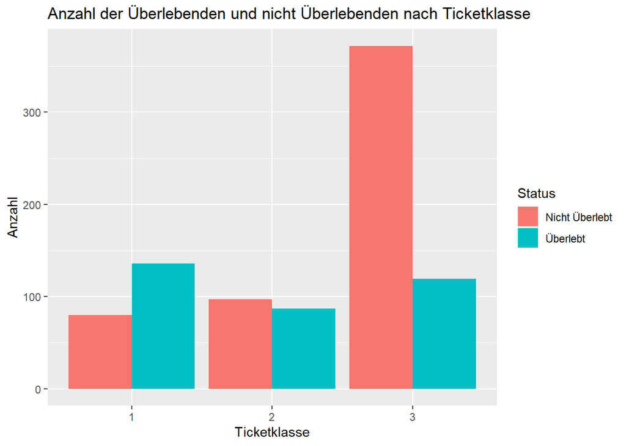

```r
library(ggplot2)
titanic_data %>%
  group_by(Pclass, Survived) %>% # Gruppierung nach Pclass und Survived
  summarize( # Zusammenfassen der Daten
    count = n(), # Anzahl der Passagiere pro Gruppe
    .groups = "drop" # Entfernen der Gruppierung
  ) %>%
  mutate(Survived = factor( # Umwandeln in einen Faktor
    Survived, # Überlebensstatus
    levels = c(0, 1), # Festlegen der Levels
    labels = c("Nicht Überlebt", "Überlebt") # Festlegen der Labels
  )) %>% # Umwandeln der Survived-Variable in einen Faktor
  ggplot(aes( # Erstellen des Plots
    x = factor(Pclass), # Umwandeln in einen Faktor
    y = count, # Anzahl der Passagiere
    fill = Survived # Färben nach Überlebensstatus
  )) +
  geom_bar(stat = "identity", position = "dodge") +
  labs(
    title = "Anzahl der Überlebenden und nicht Überlebenden nach Ticketklasse",
    x = "Ticketklasse",
    y = "Anzahl",
    fill = "Status"
  )
```

## c. Einfluss des Alters (Age)

```r
summary(titanic_data$Age)
```

```
##     Min.  1st Qu.   Median     Mean  3rd Qu.     Max.     NA's
##     0.42    21.00    28.00   530.32    39.00 44711.00      177
```

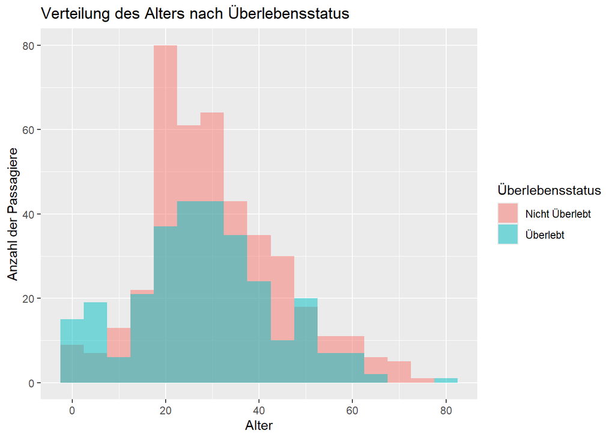

```r
titanic_data %>%
  filter(Age >= 0, Age <= 100) %>%
  ggplot(
    aes(
      x = Age,
      fill = factor(
        Survived,
        levels = c(0, 1),
        labels = c("Nicht Überlebt", "Überlebt")
      )
    )
  ) +
  geom_histogram(binwidth = 5, position = "identity", alpha = 0.5) +
  labs(
    title = "Verteilung des Alters nach Überlebensstatus",
    x = "Alter",
    y = "Anzahl der Passagiere",
    fill = "Überlebensstatus"
  )
```

3. Überprüfen Sie fehlende Werte (NA) und überlegen Sie, wie Sie damit umgehen (Bspw. Imputation).

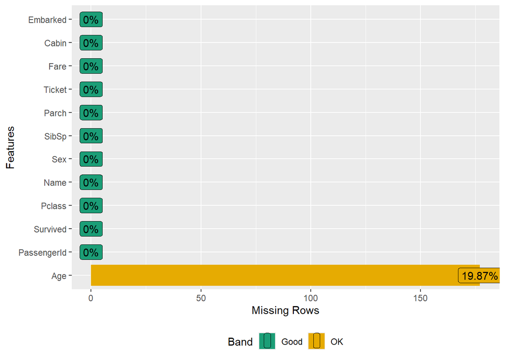

```r
library(DataExplorer) # Data exploration package
plot_missing(titanic_data)
```

```r
library(mice)
imputed_data <- mice(
  titanic_data,
  m = 10, # Anzahl der Imputationen
  maxit = 10, # Iterationen
  method = "pmm", # Predictive Mean Matching
  seed = 123 # Zufallszahlengenerator
)
titanic_data_completed <- complete(imputed_data)
```

# Schritt 2: Datenvorbereitung & Feature Engineering

```r
set.seed(123) # Setzen des Zufallszahlengenerators für Reproduzierbarkeit
library(tidymodels) # Laden des tidymodels-Pakets
titanic_data_split <-
  initial_split( # Aufteilen des Datensatzes in Trainings- und Testdaten
    titanic_data_completed, # Datensatz
    prop = 0.8 # Anteil der Trainingsdaten
  )
train_data <- training(titanic_data_split) # Trainingsdaten
test_data <- testing(titanic_data_split) # Testdaten
```

# Schritt 3: Modelle testen & evaluieren

## a. Logistische Regression

Trainieren Sie eine logistische Regression (`glm()`).

### Rezept für die logistische Regression

```r
titanic_data_recipe <- recipe(Survived ~ ., data = train_data) %>%
  # Setzen der Rolle für PassengerId
  update_role(PassengerId, new_role = "id") %>%
  # Entfernen unnötiger Spalten
  step_rm(Name) %>% # Entfernen der Spalte Name
  # Umwandlung der Variablen in Faktoren
  step_string2factor(Sex, Embarked) %>%
  # Impute with Bagging
  step_impute_bag(impute_with = imp_vars(all_predictors()), trees = 15) %>%
  # Imputation mit dem Modus für Embarked
  step_impute_mode(Embarked) %>%
  # Umwandlung der kategorialen Variablen in Dummy-Variablen
  step_dummy(all_nominal_predictors(), -all_outcomes()) %>%
  # Normalisierung der Prädiktoren
  step_normalize(all_numeric_predictors())
summary(titanic_data_recipe)
```

```
## # A tibble: 12 × 4
##    variable    type      role      source
##    <chr>       <list>    <chr>     <chr>
##  1 PassengerId <chr [2]> id        original
##  2 Pclass      <chr [3]> predictor original
##  3 Name        <chr [3]> predictor original
##  4 Sex         <chr [3]> predictor original
##  5 Age         <chr [2]> predictor original
##  6 SibSp       <chr [2]> predictor original
##  7 Parch       <chr [2]> predictor original
##  8 Ticket      <chr [3]> predictor original
##  9 Fare        <chr [2]> predictor original
## 10 Cabin       <chr [3]> predictor original
## 11 Embarked    <chr [3]> predictor original
## 12 Survived    <chr [3]> outcome   original
```

### Modelltraining

```r
model_glm <- logistic_reg() %>%
  set_engine("glm") %>% # general linearized model
  set_mode("classification") # Binomiale Klassifikation

workflow_glm <- workflow() %>%
  add_recipe(titanic_data_recipe) %>%
  add_model(model_glm)

fit_glm <- workflow_glm %>%
  fit(data = train_data)
```

### Modellbewertung

```r
predictions_glm <- fit_glm %>%
  predict(new_data = test_data) %>%
  as_tibble() %>%
  bind_cols(test_data) %>%
  select(c(PassengerId, .pred_class, Survived, everything()))
```

### Support Vector Machine (SVM) (kernlab-Paket)

```r
model_svm <- svm_rbf(cost = 1, rbf_sigma = 0.1, mode = "classification") %>%
  set_engine("kernlab")

workflow_svm <- workflow() %>%
  add_recipe(titanic_data_recipe) %>%
  add_model(model_svm)

fit_svm <- workflow_svm %>%
  fit(data = train_data)
```

```r
model_rf <- rand_forest(trees = 300, mtry = 3, mode = "classification") %>%
  set_engine("ranger")

workflow_rf <- workflow() %>%
  add_recipe(titanic_data_recipe) %>%
  add_model(model_rf)

fit_rf <- workflow_rf %>%
  fit(data = train_data)
```

## Modell Effizienz & Evaluation

```r
# Genauigkeit berechnen
accuracy_value <- predictions_glm %>%
  yardstick::accuracy(truth = Survived, estimate = .pred_class) %>%
  pull()

# Präzision berechnen
precision_value <- predictions_glm %>%
  yardstick::precision(truth = Survived, estimate = .pred_class) %>%
  pull()

# Rückruf (Recall) berechnen
recall_value <- predictions_glm %>%
  yardstick::recall(truth = Survived, estimate = .pred_class) %>%
  pull()

# Ausdrucken der Metriken
cat("Accuracy:", accuracy_value, "\n")
```

```
## Accuracy: 0.8076923
```

```r
cat("Precision:", precision_value, "\n")
```

```
## Precision: 0.72
```

```r
cat("Recall:", recall_value, "\n")
```

```
## Recall: 0.8571429
```

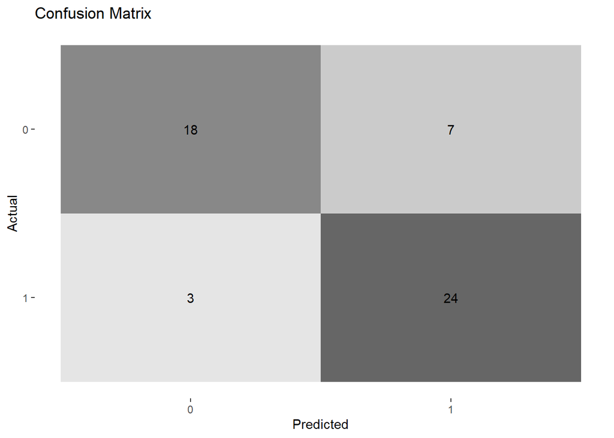

```r
conf_matrix <- conf_mat(
  predictions_glm,
  truth = Survived,
  estimate = .pred_class
)

library(ggplot2)
library(ggdist)
autoplot(conf_matrix, type = "heatmap", scale = "count") +
  ggtitle("Confusion Matrix") +
  labs(x = "Predicted", y = "Actual")
```

4. Wählen Sie das beste Modell aus und begründen Sie Ihre Entscheidung.  
   **Hinweise zur Modellwahl:**
   - Logistische Regression ist ein gutes Basismodell für binäre Klassifikation.
   - SVM kann bei komplexeren Entscheidungsgrenzen helfen. Testen Sie verschiedene Kernelfunktionen (linear, radial).
   - Random Forest kann nichtlineare Zusammenhänge erfassen und ist oft robuster gegenüber Ausreißern.

# Schritt 4: Workflow mit tidymodels & Vorhersagen für neue Passagiere

Aufgaben:

1. Erstellen Sie eine Modellpipeline mit `recipes()`, `workflows()` und `parsnip()`.
2. Nutzen Sie Cross-Validation (`rsample`), um die Performance der Modelle objektiv zu bewerten.
3. Trainieren Sie das beste Modell auf den gesamten Datensatz.
4. Laden Sie eine neue Passagierliste (`new_passengers.csv`) und sagen Sie deren Überlebenswahrscheinlichkeit vorher.  
   **Hinweise zur Modellimplementierung:**
   - Verwenden Sie das tidymodels-Framework, um Ihre Modelle sauber zu strukturieren.
   - `workflows()` hilft, Vorverarbeitung (`recipes()`) und Modelltraining zu kombinieren.
   - Nutzen Sie predict(), um auf neue Passagiere angewendet zu werden.

# Schritt 5: Präsentation der Ergebnisse

Bereiten Sie eine kurze Präsentation mit folgenden Inhalten vor:

1. EDA & Datenaufbereitung – Welche Entscheidungen wurden getroffen?
2. Vergleich der Modelle – Welche Modelle wurden getestet und warum?
3. Wahl des besten Modells – Welche Ergebnisse führten zur Entscheidung?
4. Vorhersagen für neue Passagiere – Welche Unsicherheiten gibt es?